# Flexible Damage Functions

Author

James Rising, Sebastian Cadavid Sanchez, Climate Impact Lab

Published

April 30, 2026

## 0.1 Labor: Low Risk

Flexible damage function parameters at the Impact Region level.

**Outcome units:** `portion` — dimensionless fraction of low-risk-worker labor productivity, rebased to 2005 baseline (negative = productivity loss)

$$D_{it} = (\alpha_i T_t + \beta_i T_t^2) \cdot Y_{it}^{\gamma}$$

where $\gamma$ is the income elasticity (fitted globally), $\alpha_i$ is the linear coefficient, and $\beta_i$ is the quadratic coefficient.

# 1 Global Estimation

## 1.1 Income Elasticity Estimation

The income elasticity $\gamma$ is estimated using a fixed-effects regression:

$$y_{it} = \gamma \cdot \log(Y_{it}) + \mu_{g(i,T)} + \nu_t + \varepsilon_{it}$$

where $\mu_{g(i,T)}$ are region-by-temperature-bin fixed effects and $\nu_t$ are year fixed effects.

Table 1: Income Elasticity (Gamma) Estimation Results

| Statistic | Value |
| --- | --- |
| Income elasticity ($\gamma$) | -0.0039 |
| Standard error | 6.23e-04 |
| 95% CI | [-0.0051, -0.0027] |
| R-squared | 0.9864 |
| Observations | 24,958,476 |
| Regions | 24,326 |
| Gamma quantiles | 19 |

# 2 Parameter Distributions

## 2.1 8-Panel Summary

Row 1: gamma, alpha, beta, rsqr1. Row 2: rho, zeta, eta, rsqr2.

```
Using median gamma: -0.003916, 72,978 rows (of 462,194 total)
```

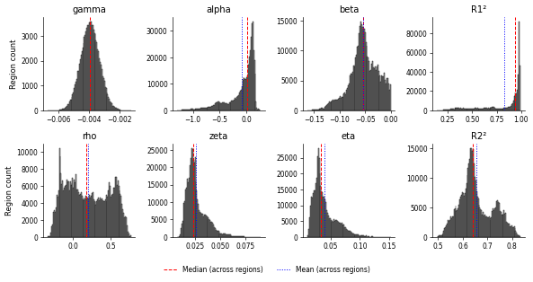

Figure 1: Distribution of Regional Parameters

## 2.2 Projection Equation and Parameter Definitions

The estimated parameters are used to project damages via Monte Carlo sampling:

$$D_{it}^k = (\hat{\alpha}_{ik} T_t + \hat{\beta}_{ik} T_t^2) Y_{it}^{\hat{\gamma}_k} + \hat{\theta}_{ik} T_t Y_{it}^{\hat{\gamma}_k} + \hat{\phi}_{it}^k$$

where $k$ indexes the Monte Carlo draw. The parameters in each row of the output CSV control distinct components of this equation:

- **gamma**: income elasticity $\hat{\gamma}_k$, one of 19 quantile values drawn from $N(\hat{\gamma}, SE(\hat{\gamma}))$
- **alpha, beta**: linear and quadratic temperature coefficients; $\hat{\alpha}_{ik}$ and $\hat{\beta}_{ik}$ are drawn from the joint normal defined by the VCV below
- **sigma11, sigma12, sigma22**: variance-covariance matrix of $(\alpha, \beta)$, used for joint uncertainty sampling
- **rho**: correlation between regional and global polynomial residuals $\rho_i$, used to maintain spatial covariance across regions in Monte Carlo draws
- **zeta**: temperature-dependent error scale $\zeta_{ik}$; the run-specific error term $\hat{\theta}_{ik}$ is drawn from $N(0, \zeta_{ik})$
- **eta**: residual noise standard deviation $\eta_{ik}$; the annual noise $\hat{\phi}_{it}^k$ is drawn from $N(0, \eta_{ik})$
- **rsqr1, rsqr2**: polynomial fit quality and error model fit, respectively

## 2.3 Summary Statistics

Table 2: Regional Parameter Summary

| Parameter | Mean | Median | Std | Min | Max | N |
| --- | --- | --- | --- | --- | --- | --- |
| alpha | -0.09045 | 0.01635 | 0.2764 | -1.283 | 0.2665 | 24,326 |
| beta | -0.0529 | -0.05302 | 0.02806 | -0.162 | 0 | 24,326 |
| rho | 0.1995 | 0.1776 | 0.2801 | -0.3345 | 0.7631 | 24,326 |
| zeta | 0.02658 | 0.02402 | 0.01013 | 0.007811 | 0.08904 | 24,326 |
| eta | 0.03939 | 0.0331 | 0.01969 | 0.00953 | 0.1507 | 24,326 |
| rsqr1 | 0.8239 | 0.9424 | 0.2184 | 0.1386 | 0.9937 | 24,326 |
| rsqr2 | 0.6555 | 0.6412 | 0.06847 | 0.495 | 0.8332 | 24,326 |

# 3 Spaghetti Curves

Regional damage function curves showing D(T) = αT + βT² for sampled regions.

[interactive chart not shown]

Figure 2: Regional Damage Functions

# 4 Zero Crossings

The zero crossing (extremum) of the parabola occurs at $T^* = -\alpha / (2\beta)$.

Table 3: Zero Crossing Statistics

| Category | Count | Percentage |
| --- | --- | --- |
| β = 0 (no crossing) | 118 | 0.5% |
| T > 20°C (beyond graph) | 131 | 0.5% |
| T < 0°C (negative crossing) | 11486 | 47.2% |
| Valid crossings (0-20°C) | 12591 | 51.8% |

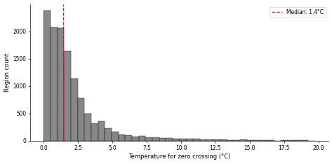

Figure 3: Distribution of Zero Crossing Temperatures

# 5 Slope Analysis

Maximum slope between 0 and 10°C: $\frac{dM}{dT} = \alpha + 2\beta T$

The maximum occurs at either T=0 or T=10 (endpoints of interval).

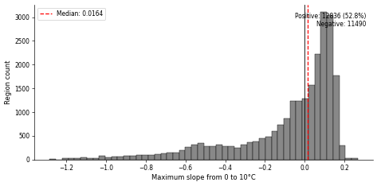

Figure 4: Distribution of Maximum Slopes (0-10°C)

*Convexity analysis omitted (beta constraint active).*

# 6 R-squared Analysis

## 6.1 Polynomial Fit Quality (rsqr1)

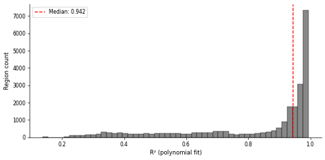

Figure 5: Regional Fit Quality (R-squared)

## 6.2 Error Model R-squared (rsqr2) Quantiles

Table 4: rsqr2 Quantiles

| 0% (Min) | 25% | 50% (Median) | 75% | 100% (Max) |
| --- | --- | --- | --- | --- |
| 0.4950 | 0.6094 | 0.6412 | 0.7073 | 0.8332 |

# 7 Modelled Variance

Modelled variance statistic: $1 - \frac{\sum_i \eta_i^2}{\sum_i D_i^2}$

Table 5: Modelled Variance Statistics

| Statistic | Value |
| --- | --- |
| Modelled variance | 0.9986 |
| Sum(η²) | 47.1667 |
| Sum(D²) at T=3.0°C | 33962.5928 |
| N regions | 24,326 |

# 8 Best- and Worst-Fitting Regions

The 3 worst- and 3 best-fitting regions by R-squared, with raw simulation data overlaid on the fitted polynomial curve. **Red rows = worst fits**, **green rows = best fits**.

Table 6: Best- and worst-fitting regions

Top 3 best fit (R²) Top 3 worst fit (R²)

| Region | α | β | η | R² |
| --- | --- | --- | --- | --- |
| EGY.2 | -0.624 | -0.049 | 0.0417 | 0.994 |
| SDN.3.10.44.149 | -0.673 | -0.0444 | 0.0435 | 0.994 |
| IDN.23.292 | -0.215 | -0.0878 | 0.0296 | 0.993 |
| AUS.7.932 | 0.0509 | -0.0114 | 0.0158 | 0.139 |
| AUS.7.940 | 0.0456 | -0.0112 | 0.0155 | 0.139 |
| AUS.7.883 | 0.0511 | -0.0116 | 0.0159 | 0.14 |

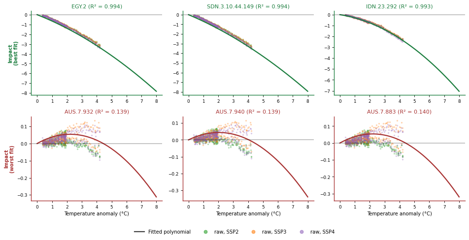

# 9 Regional Parameter Maps

Maps of key parameters at the **impact region** level. Red = negative (damage increases with T), Blue = positive.

## 9.1 Alpha (Linear Coefficient)

Alpha ($\alpha$) represents the linear sensitivity to temperature. Regions with negative alpha experience damage that increases with the first degree of warming.

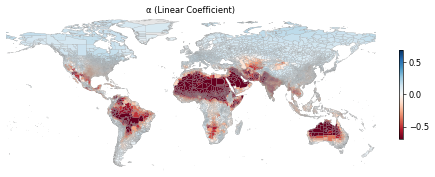

Figure 7: α (linear coefficient)

## 9.2 Beta (Quadratic Coefficient)

Beta ($\beta$) represents the curvature of the damage function.

The concavity ($\beta \leq 0$) constraint is enforced for this sector, meaning optimal temperature exists, damages accelerate beyond it.

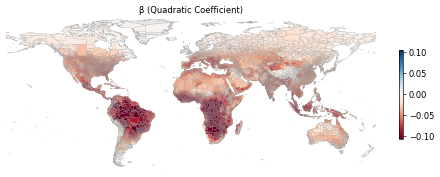

Figure 8: β (quadratic coefficient)

## 9.3 R-squared (Fit Quality)

$R^2$ measures the polynomial fit quality. Higher values indicate that the quadratic form captures more of the variance in the data.

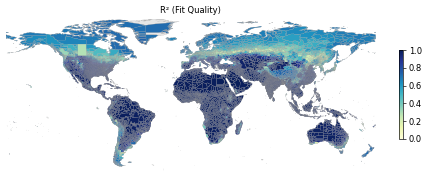

Figure 9: R² (stage 1 fit quality)

# 10 F2: Flex vs Raw Comparison

Comparison of flexible damage function predictions against raw simulation means.

For each scenario (RCP × SSP × Model), we compute at the final year:

- **Flex predicted**: $(\alpha \cdot T + \beta \cdot T^2) \cdot Y^\gamma$
- **Raw actual**: The outcome variable (y) from the source data

**Year 2099**: 292,536 rows

**rcp45**

**SSP2**

**high**

**Correlation:** 0.9748 | **RMSE:** 0.711040 | **Sign agreement:** 95.3%

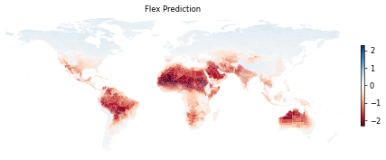

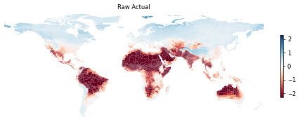

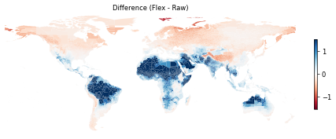

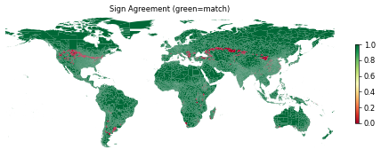

[interactive chart not shown]

Top 5 best predicted Top 5 worst predicted

Year 2099 · T<sub>mean</sub> across these regions: 1.96°C

| Region | Raw | Flex | Residual |
| --- | --- | --- | --- |
| LBY.8 | -0.225 | -0.225 | 1.80e-6 |
| CHN.15.169.1150 | -0.0953 | -0.0953 | -1.83e-5 |
| USA.44.2747 | -0.699 | -0.699 | 3.07e-5 |
| USA.38.2235 | -0.339 | -0.339 | -3.84e-5 |
| USA.11.524 | -0.409 | -0.409 | -3.89e-5 |
| SOM.7.29 | -7.36 | -1.77 | 5.58 |
| SOM.2.6 | -6.75 | -1.62 | 5.13 |
| SOM.7.R33e9ff1321647aad | -6.34 | -1.57 | 4.77 |
| MLI.2.4 | -7.2 | -2.48 | 4.72 |
| SOM.8.Rfccc5a812678586e | -6.13 | -1.43 | 4.7 |

**low**

**Correlation:** 0.9664 | **RMSE:** 0.873986 | **Sign agreement:** 95.9%

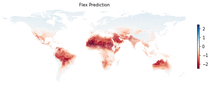

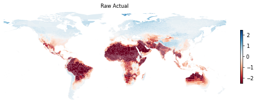

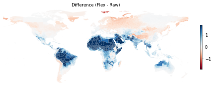

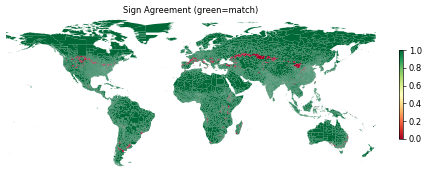

[interactive chart not shown]

Top 5 best predicted Top 5 worst predicted

Year 2099 · T<sub>mean</sub> across these regions: 1.96°C

| Region | Raw | Flex | Residual |
| --- | --- | --- | --- |
| CHN.23.242.1605 | -0.234 | -0.234 | -4.63e-6 |
| RUS.13.389.389 | 0.172 | 0.172 | -5.85e-6 |
| USA.19.1159 | -0.333 | -0.333 | 3.13e-5 |
| GBR.4.175 | 0.108 | 0.108 | 4.07e-5 |
| USA.43.2514 | -0.0531 | -0.0531 | -5.63e-5 |
| BFA.29 | -8.38 | -2.38 | 6 |
| NER.7.31 | -8.19 | -2.34 | 5.86 |
| TCD.1.1 | -8.18 | -2.43 | 5.74 |
| NER.7.28 | -8.02 | -2.31 | 5.72 |
| MLI.2.4 | -8.2 | -2.49 | 5.71 |

**SSP3**

**high**

**Correlation:** 0.9759 | **RMSE:** 1.149456 | **Sign agreement:** 95.7%

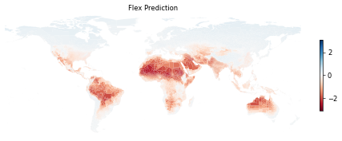

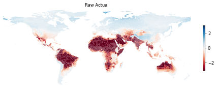

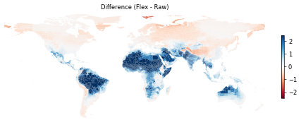

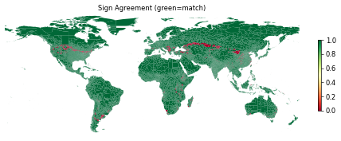

[interactive chart not shown]

Top 5 best predicted Top 5 worst predicted

Year 2099 · T<sub>mean</sub> across these regions: 1.96°C

| Region | Raw | Flex | Residual |
| --- | --- | --- | --- |
| USA.26.1566 | -0.289 | -0.289 | -1.28e-5 |
| USA.34.1961 | -0.195 | -0.195 | -2.36e-5 |
| DZA.12.R62d2ed18f92cd4e7 | -0.117 | -0.117 | 6.85e-5 |
| JPN.21.918 | -0.00873 | -0.0088 | -7.02e-5 |
| ESP.13.44.327.7625 | -0.0173 | -0.0174 | -8.36e-5 |
| MLI.2.4 | -9.2 | -2.5 | 6.7 |
| MLI.9.47 | -9.06 | -2.4 | 6.66 |
| MLI.2.3 | -9 | -2.42 | 6.58 |
| MLI.9.48 | -8.99 | -2.42 | 6.57 |
| MLI.9.49 | -8.95 | -2.38 | 6.57 |

**low**

**Correlation:** 0.9585 | **RMSE:** 1.229596 | **Sign agreement:** 93.9%

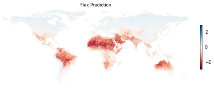

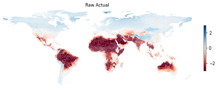

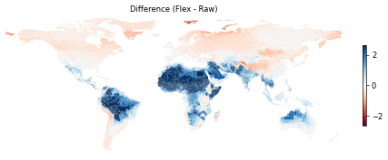

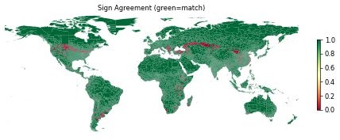

[interactive chart not shown]

Top 5 best predicted Top 5 worst predicted

Year 2099 · T<sub>mean</sub> across these regions: 1.96°C

| Region | Raw | Flex | Residual |
| --- | --- | --- | --- |
| SYR.13.48 | -0.184 | -0.184 | 8.19e-6 |
| NPL.5.13.66 | -0.203 | -0.203 | 1.45e-5 |
| MAR.1.2 | -0.142 | -0.142 | 4.81e-5 |
| AUS.6.435 | -0.0019 | -0.00183 | 7.10e-5 |
| AUS.6.464 | -0.00223 | -0.00211 | 1.14e-4 |
| TCD.1.1 | -10.3 | -2.45 | 7.89 |
| BFA.29 | -10.2 | -2.39 | 7.76 |
| MLI.2.4 | -10.3 | -2.51 | 7.76 |
| MLI.9.47 | -10.2 | -2.41 | 7.74 |
| TCD.1.3 | -10.1 | -2.44 | 7.67 |

**SSP4**

**high**

**Correlation:** 0.9391 | **RMSE:** 1.010858 | **Sign agreement:** 96.2%

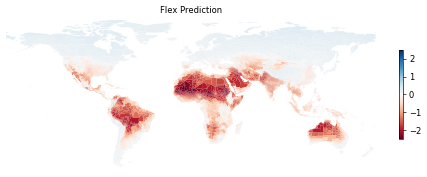

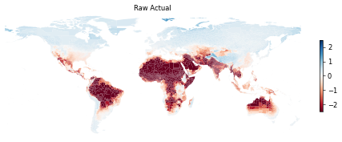

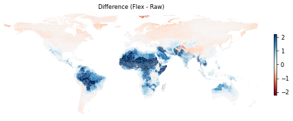

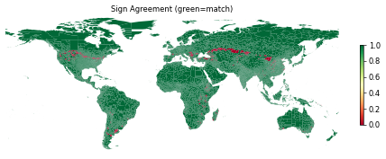

[interactive chart not shown]

Top 5 best predicted Top 5 worst predicted

Year 2099 · T<sub>mean</sub> across these regions: 1.96°C

| Region | Raw | Flex | Residual |
| --- | --- | --- | --- |
| DEU.11.30.R223df96614846c60 | 0.104 | 0.104 | 1.71e-5 |
| AUS.6.859 | -0.0656 | -0.0656 | -3.59e-5 |
| AUS.6.487 | -0.0456 | -0.0457 | -3.68e-5 |
| BRA.25.4793.9151 | 0.0891 | 0.0891 | 4.34e-5 |
| USA.4.149 | -0.52 | -0.519 | 6.71e-5 |
| MLI.2.4 | -9.64 | -2.5 | 7.14 |
| MLI.9.47 | -9.47 | -2.4 | 7.07 |
| MLI.2.3 | -9.44 | -2.42 | 7.02 |
| ERI.4.R34a4333b5b0c8f4a | -9.27 | -2.27 | 7 |
| MLI.9.48 | -9.42 | -2.42 | 7 |

**low**

**Correlation:** 0.9630 | **RMSE:** 1.172748 | **Sign agreement:** 96.2%

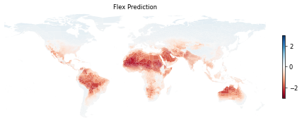

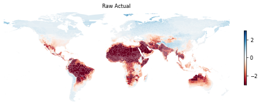

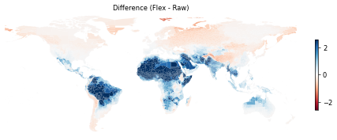

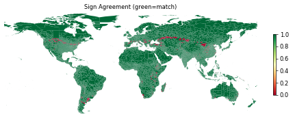

[interactive chart not shown]